# IntroToR

BIGsummer

6/23/2020

## R Markdown and Code Chunks

```r
# This is a code chunk.
```

## Importing Data and Selecting Columns

We will learn to import data into R and reshape it into formats that are useful for data visualization. For our research question, we will work with public COVD19 data to visualize the number of COVID19 cases per million for every state in the form of a heatmap and imagine other ways we would want to visualize this kind of information.

```r
# This is just repeating the commands that we did in the first day(s) to import our data.

alldata <- read.csv("us_states_covid19_daily.csv", sep = ",")
statepop <- read.csv("States.csv", sep = ",")

allpositivecases <- data.frame(alldata$date, alldata$state, alldata$positive)
selectedpops <- data.frame(statepop$State, statepop$StateAbbreviation,
                           statepop$Pop.millions)
```

## Data Wrangling and Cleaning

We will learn to handle imperfect data sets, calculate new columns, clean and rename data for downstream uses.

```r
# Merging the tables
tablemerge <- full_join(allpositivecases, selectedpops,
                        by = c("alldata.state" = "statepop.StateAbbreviation"))

# Cleaning the data
casespermillion <- tablemerge %>%
  mutate(Log2_CPM=log2(alldata.positive/statepop.Pop.millions)) %>%
  filter(statepop.Pop.millions != "NA") %>%
  filter(Log2_CPM != -Inf)

# Selecting and renaming columns, forplotting will be used for multiple types of plots.
forplotting <- casespermillion %>%
  select(alldata.date, alldata.state, Log2_CPM, alldata.positive, statepop.Pop.millions) %>%
  rename(Date = alldata.date, State = alldata.state, Positive = alldata.positive, PopMill = statepop.Pop.millions)
```

## Visualizing with heatmaps

In this lesson, we will learn to restructure our data in order to work with data visualization packages.

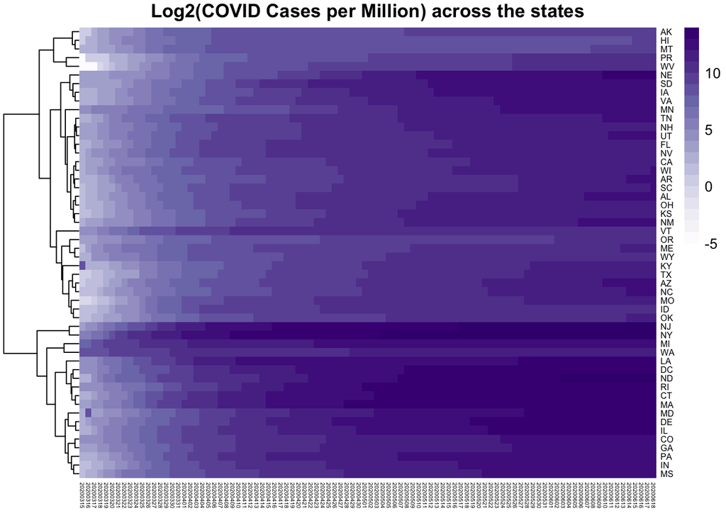

```r
# Reshaping the data frame based on State and Date information
forheatmapcpm <- forplotting %>%
  select(State, Date, Log2_CPM) %>%
  group_by(State, Date) %>%
  spread(key = Date, value = Log2_CPM)

# Cleaning and Trimming the Data set
forheatmapcpm <- column_to_rownames(forheatmapcpm, var = "State")
forheatmapcpm[is.na(forheatmapcpm)] <- min(forheatmapcpm, na.rm=TRUE)

forheatmaptrim <- forheatmapcpm[
  which(colnames(forheatmapcpm)=="20200315"):(ncol(forheatmapcpm))
  ]

# Creating the matrix
cpmmatrix <- as.matrix(forheatmaptrim)

# Perparing for Visualization
cpmbreaks <- as.integer(min(forheatmapcpm-1)):as.integer(max(forheatmapcpm))

# Syntax for pheatmap()
cpmplot <- pheatmap(
  cpmmatrix,
  scale="none",
  cluster_cols = FALSE,
  breaks = cpmbreaks,
  color = colorRampPalette(brewer.pal(9, "Purples"))(length(cpmbreaks)),
  border_color = NA,
  fontsize_col = 4,
  fontsize_row = 6,
  main = "Log2(COVID Cases per Million) across the states"
  )
```

## Data Visualization with ggplot2

We will learn about the grammar of graphics and use ggplot2 to create some common plots.

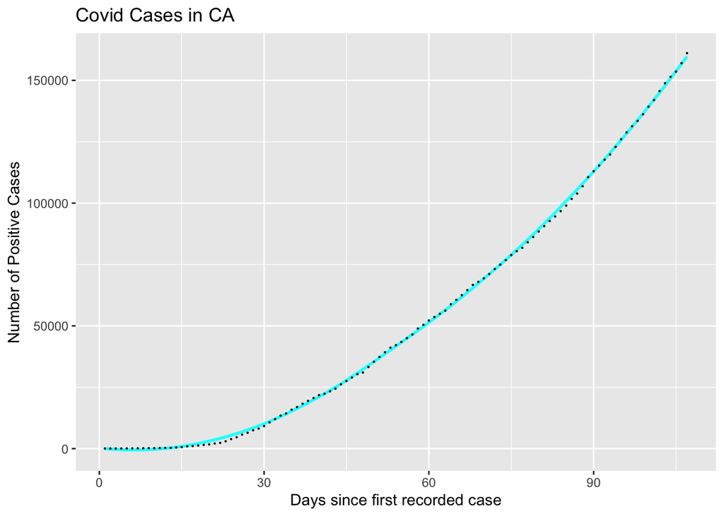

```r
# Selecting the data
forplotting <- casespermillion %>%
  select(alldata.date, alldata.state, Log2_CPM, alldata.positive) %>%
  rename(Date = alldata.date, State = alldata.state, Positive = alldata.positive)

# Pick a state
justca <- forplotting %>%
  filter(State == "CA")

# How many days since data collection first started?
justca <- justca %>%
  mutate(Days = nrow(justca):1)

# The Plot
plot <- ggplot(justca, aes(x = Days, y = Positive)) +
  geom_smooth(method = "auto", color = "Cyan") +
  geom_point(size = 0.1, alpha = 1) +
  labs( x = "Days since first recorded case", y = "Number of Positive Cases", title = "Covid Cases in CA")

plot
```

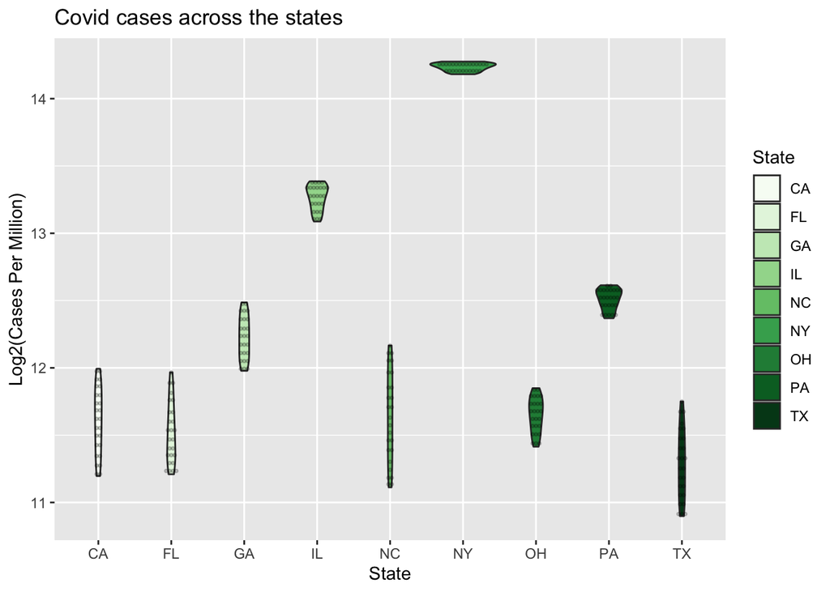

```r
# Selecting the data
forplotting <- casespermillion %>%
  select(alldata.date, alldata.state, Log2_CPM, alldata.positive, statepop.Pop.millions) %>%
  rename(Date = alldata.date, State = alldata.state, Positive = alldata.positive, PopMill = statepop.Pop.millions)

# Filter your states.
forplotting <- forplotting %>%
  filter(PopMill > 10) # with populations over 10 Million

# Filter the dates
forplotting <- forplotting %>%
  filter(Date > 20200523) # any day after 2020-05-23


ggplot(data = forplotting, aes(State, Log2_CPM, fill = State))+
  geom_violin(scale = "area")+
  geom_dotplot(binaxis="y", stackdir = "center", binwidth = 0.05, dotsize = .5, fill = "black", alpha = 0.2) +
  scale_fill_brewer(palette = "Greens") +
  labs( y = "Log2(Cases Per Million)", title = "Covid cases across the states")
```

## How else would you do it?